# The Science of Crawl (2): Content Freshness

In our [previous post](http://blog.urx.com/urx-blog/2014/9/4/the-science-of-crawl-part-1-deduplication-of-web-content) we introduced a funnel for deduplicating web documents within a search index. The dual problems of exact duplicate and near duplicate web document identification are considered. By chaining together several methods with increasing specificity we identify a system which provides sufficient precision and recall with minimal computational tradeoffs.

In this post, we look at a second challenge of maintaining a continually evolving corpus of web documents: content freshness. Roughly, freshness can be broken down into two categories: search tuning and corpus freshness.

Search tuning is performed to ensure documents returned for any given query are temporally relevant. For example, a query for $San\ Francisco\ Giants\ tickets$ should return documents for tickets to this week's World Series game, such as [this Seatgeek document](https://seatgeek.com/world-series-kansas-city-royals-at-san-francisco-giants-game-3-tickets/10-24-2014-san-francisco-california-at-t-park/mlb/2329744/) or [this StubHub document](http://www.stubhub.com/san-francisco-giants-playoff-tickets/giants-vs-royals-10-24-2014-9131041/). Returning a link to a Giants playoff game from last week would be of little use. Search tuning is performed to evaluate the tradeoff between [text relevancy](http://en.wikipedia.org/wiki/Tf%E2%80%93idf) and temporal relevancy. Search relevancy is a deep and subtle problem, worthy of its own blog post. We instead focus on the second, crawl-focused category, content freshness.

Content freshness is the problem of balancing resources between crawling previously unseen pages on the web and *recrawling* webpages that are already in an index. The reason for recrawling pages is to ensure that indexed copies of each web page are as up-to-date as possible. The web is dynamic. Pages are likely to change between the last time they were indexed and the time when they were queried. If the text on a web page has changed significantly since the page was last indexed, the local (indexed) copy is said to be *stale*. Similarly, a local copy of a page is *fresh* if it accurately reflects the live web. Stale pages in an index can mislead search engines. Consider the extreme case, a user searching for $Barack\ Obama\ New\ York\ Times$. If the local copy of *nytimes.com* is stale (say from November 5th 2011), the front page of the New York Times could be recommended as a relevant document because of a story on Obama's election. The search engine identifies the New York Times home page as relevant content, and surfaces nytimes.com to the user. The issue is that the current New York Times page has long since changed. This is known as a false positive search result. Index freshness can also lead to false negative search results, i.e. failing to surface a result because the local index has less relevancy to the user's query than the current web page.

## Problem

In an ideal world, pages in the crawler's index would be continually refreshed, ensuring that indexed content mirrors the present web. However, constraints on time, bandwidth and disk space force practical limits on the frequency with which content can be refreshed. With this in mind, let's build an optimal page refresh strategy.

[Olston and Najork](http://infolab.stanford.edu/~olston/publications/crawling_survey.pdf) provide a fantastic overview of the history of the field of freshness. They separate content freshness into two sub-categories: binary and continuous freshness models. Binary models force the assumption that pages are either perfectly fresh or completely stale. This harsh assumption can lead to some counter-intuitive results, most notably that the optimal refresh strategy is uniform resource allocation. This forces a recrawler to effectively *ignore* pages whose content change frequently in favor of more static pages.

Because we aim to build a model which encourages recrawling fast, dynamic pages, we instead consider the second category, continuous models. In a first order, continuous freshness model, a local page is considered as fresh as the last time it was crawled. That is, freshness of a page in an index is inversely proportional to the time since the page was last crawled. There have been several researchers who have investigated continuous freshness models. Unfortunately most published literature separates content freshness (recrawling indexed pages) from content expansion (crawling new pages). We argue that the two are intimately tied. An organization has a certain *fixed utility* which must be distributed between the content freshness and expansion. With this in mind, there are two key papers describing the balance of these two processes. The first, [Olston's User Centric Web Crawling](http://i.stanford.edu/~olston/publications/userCentricCrawling.pdf) focuses on allocating resources to minimize the impact on search relevancy. The general mantra is expand and refresh content which is commonly queried by users. The second, [Olston's Recrawl Scheduling based on Information Longevity](http://infolab.stanford.edu/~olston/publications/www08.pdf) uses an information theoretic approach to refresh content which appears stale. To focus on the science of crawling, agnostic of the system built on such a crawl index, we focus on this second paper.

Here, $F(P)$ refers to the [w-shingles](http://en.wikipedia.org/wiki/W-shingling) of page $P$. The Jaccard metric measures the number of w-shingles in common between pages $P$ and $P'$, normalizing by the total number of unique w-shingles. Splitting the document into such features allows for a more continuous metric than the binary model.

Given that we've defined a pairwise page metric, let's now formulate the *optimal* page refresh function. Rephrased, for a fixed number of page refreshes, let's formulate the optimal re-crawl schedule. It can be shown that for any monotonically increasing divergence function, D, the following *utility function* is in fact optimal.

$$ U_P(t) = t * D_P(t) - \int_0^t{D_p(t')dt'} $$

This function seems complex but it's intuitive. Breaking it down piece by piece, $U_P(t)$ is the Utility of refreshing page $P$ at time $t$ given a global, fixed, per-page resource limit, $T$. In practice, a page will be re-crawled when $U_P(t) = T$. This utility is inversely proportional to the integral of $D_P(t)$ over all of observed time. This integral can be thought of as the net change in page $P$ between the time $P$ was last indexed and $t$. Therefore, the more a page changes, the smaller the utility will be and the more frequently the page will meet the minimum requirement $T$ to be refreshed. The constant $t * D_P(t)$ is added to $U$ to rescale.

As a quick aside, determining $T$ *a priori* is a difficult problem. It remains a business decision how much utility should be devoted to crawl freshness versus crawl coverage and is problem dependent. In practice, this number is approximated and tuned relative to some external, business focused metric (click through rate, revenue, burn rate, AWS bill, etc.).

Calculating $U_P(t)$ requires two stages, offline learning and online evaluation.

## Offline learning

Let's assume a crawler has indexed the same page several times over the period of a few weeks. To evaluate utility we must first estimate $D_P(t)$. Every time a page is re-crawled, the Jaccard distance is calculated between that page and all previous crawls of the page. This requires storing the distance between all pairwise combinations of page instances. This is stored as a list of tuples. Let's say we have 4 versions of a page in the index $P_1, P_2, P_3, P_4$ indexed uniformly on days 1, 2, 3, 4. We can write the tuples (time, distance) as:

$$ [(1,\ D(P_1,P_2)),\ (1,\ D(P_2,P_3)),\ (1,\ D(P_3, P_4)),\\ \ (2,\ D(P_1,P_3)),\ (2,\ D(P_2,P_4)),\ (3,\ D(P_1,P_4))] $$

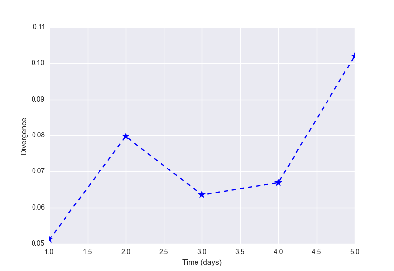

```python
from IPython.core.display import Image
Image(filename='D.png')
```

Now that we have defined a discrete distribution, $D_P(t)$, we integrate to evaluate $U_P(t)$. However, being a discrete distribution, we have to map $D$ to a continuous function before integration. The naive mapping is called linear interpolation (i.e., connect-the-dots). Such a fit would look like the dashed line in the figure above. While this gives a nice fit to $D$, it breaks the principle stated before that utility is only maximized under a monotone ('ever increasing') function. Furthermore, it is likely that linear interpolation is overfitting the divergence of this exact page given our limited, 5 day sample size. Instead, we *approximate* a continuous $D_P(t)$ by fitting two separate Poisson-like distributions and choosing the better fit. The two equations are written below:

$$ D_P^1(t) \approx 1 - e^{-\lambda_R*t} \\ D_P^2(t) \approx 1 - \sum_{i=0}^{K-1}\frac{(\lambda_R*t)^i*e^{-\lambda_R*t}}{i!} $$

$D_P^1(t)$ describes page content as a "churn" model wherein page content is overwritten at a predictable, average rate. $D_P^2(t)$ describes a "scroll" like page wherein K new content pieces are appended at a predictable, average rate (like comments on a blog post). We are not limited to only these two models. Any monotone function reasonably describing web content change can be fit and compared with the above models. For simplicity we stick with these models and show the best fits below:

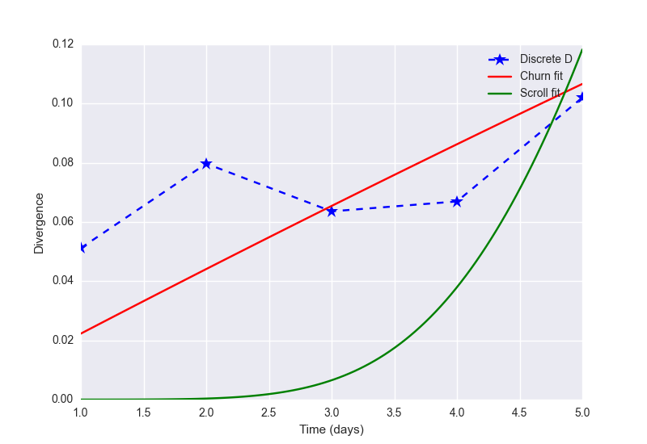

```python
Image(filename='D_interp.png')
```

A least squares method is used to find the optimal parameters to fit the Churn and Scroll models. The model with a smaller absolute error is chosen. In the above example, the churn model would be used as it better approximates the discrete function. It is worth noting that K itself cannot easily be fit via gradient descent as it takes on discrete, integer values. In this case it is valuable to fit several K>=2 models so long as the least squares error continues to decrease with increased K.

Now that a continuous approximation to our divergence has been formed, let's solve for the time, $t$, which solves the following integral equation:

$$ T = t * D_P(t) - \int_0^t{D_p(t')dt'} $$

As a first step, rewrite the equation as the equivalent root-finding problem

$$ 0 = t * D_P(t) - \int_0^t{D_p(t')dt'} - T $$

Let's take a look at a python implementation:

```python
from __future__ import division
import sys
import numpy as np
from scipy.integrate import quad
from scipy.optimize import curve_fit, newton
from math import factorial
from settings import T, K, PLOTTER

def shingle_page(htmlpage, width):
    """
    Return w-shingles of a page
    """
    splitpage = htmlpage.split()
    shingles = [' '.join(splitpage[i:i + width]) for i in \
                         xrange(max(len(splitpage) - width + 1, 1))]
    return shingles

def D(page1, page2):
    """
    Pairwise page distance metric. Jaccard on w-shingles
    """
    p1 = set(page1)
    p2 = set(page2)

    jaccard_dist = len(p1 & p2) / len(p1 | p2)

    return 1-jaccard_dist

def churn(t, lambda_r):
    """
    The churn or repeated overwrite model
    """
    return 1 - np.exp(-lambda_r * t)

def churn_fit(t, U):
    """
    Use least squares to fit the churn model
    """
    t = np.array(t)
    U = np.array(U)

    return curve_fit(churn, t, U)

def frag(t, lambda_r):
    """
    The fragment or perodic update model.
    K is globally fixed for now.
    """
    tsum = 0
    for i in range(K):
        tsum += ((lambda_r * t) ** i * np.exp(-lambda_r * t)) / factorial(i)
    return 1 - tsum

def frag_fit(t, U):
    """
    Use least squares to fit the fragment model
    """
    t = np.array(t)
    U = np.array(U)

    return curve_fit(frag, t, U)

def optimize_refresh_time(ufunc, lambda_r, T, t_guess=5):
    """
    Newton Raphson root finder
    """
    return newton(ufunc, t_guess, args=(lambda_r, T))

def churn_util(t, lambda_r, T):
    """
    solve: t*D - integral(D) - T = 0
    D := churn
    """
    return t * churn(t, lambda_r) - quad(lambda t: churn(t, lambda_r), 0, t)[0] - T

def frag_util(t, lambda_r, T):
    """
    solve: t*D - integral(D) - T = 0
    D := fragment
    """
    return t * frag(t, lambda_r) - quad(lambda t: frag(t, lambda_r), 0, t)[0] - T


def eval_change_profile(pages):
    """
    Return the change profile tuples (t, D(P1, P2))
    and discrete divergence function D(t)
    """
    pagelist = []
    for page in pages:
        with open(page, 'r') as fopen:
            pagelist.append(fopen.read())

    shinglelist = [shingle_page(page, 3) for page in pagelist]

    npages = len(shinglelist)
    change_profile = dict()
    for i in range(npages):
        for j in range(i+1, npages):
            tdiff = j - i
            if tdiff in change_profile:
                change_profile[tdiff].append(D(shinglelist[i], shinglelist[j]))
            else:
                change_profile[tdiff] = [D(shinglelist[i], shinglelist[j])]

    divergence = [np.mean(np.array(change_profile[i]))
               for i in change_profile.keys()]

    return change_profile, divergence


def get_update_time(pages):
    # For a sequence of page divergences, return the "change profile"
    change_profile, divergence = eval_change_profile(pages)

    # Fit two page change models: "churn" and "fragment"
    churn_param, churn_e = churn_fit(change_profile.keys(), divergence)
    frag_param, frag_e = frag_fit(change_profile.keys(), divergence)

    # Use the model which fits better
    if abs(churn_e[0]) < abs(frag_e[0]):
        refresh_at = optimize_refresh_time(churn_util, churn_param[0], T)
    else:
        refresh_at = optimize_refresh_time(frag_util, frag_param[0], T)

    return refresh_at


if __name__ == '__main__':
    """
    to run, save as freshness.py and run:

    >> python freshness.py pageDay0.html pageDay1.html pageDay2.html ...
    """
    pages = sys.argv[1:]
    timeToRefresh = get_update_time(pages)
    print 'Time to refresh %f' % timeToRefresh
```

## Seeding the model

Initial population of the index should be performed via uniform page refreshes at a rate affordable given our utility. This provides the best possible statistics for $D_P(t)$. Ideally, error of the fit Poisson distribution should be tracked every time a new page is added. The error should decrease over time and a transition from uniform refreshes to the above recrawl policy occurs after the error drops below a reasonable, global threshold $\epsilon$.

Unfortunately, following a uniform refresh policy may be difficult at web scale. One possible alternative involves a page classifier. Such a classifier could group front pages (often filled with dynamic content) and main content (news articles, songs, artist profiles, recipes, etc.) which is less likely to change with time using features such as URL, page w-shingles, CSS classes, etc. More careful focus can be placed on instantiating models for pages classified as dynamic.

## Online: caching parameters, recalculating Poisson, etc.

In an ideal world, $D_P(t)$ would be recalculated every time a page is recrawled to improve the estimate for the next recrawl time, $t'$. Unfortunately this is not feasible for every web page, for every recrawl. A recalcuation is a low memory (per page) operation: simply re-average the discrete distribution, fit with a series of Poisson-like distributions and find the $t$ solving $U_P(t)=T$. After some initial overhead of initializing these per page models, it is discovered that a majority of crawled pages *do not* change significantly with time. Given a large enough resource pool, it is not out of the question that models can be refit for the handful of truly dynamic pages.